# beetles

http://www.openbugs.net/Examples/Beetles.html

The dataset describes the effect of some quantities of insecticide on a given number of beetles. It contains records of amount of insecticide x_i used, number of initial beetles n_i and dead beetles r_i.

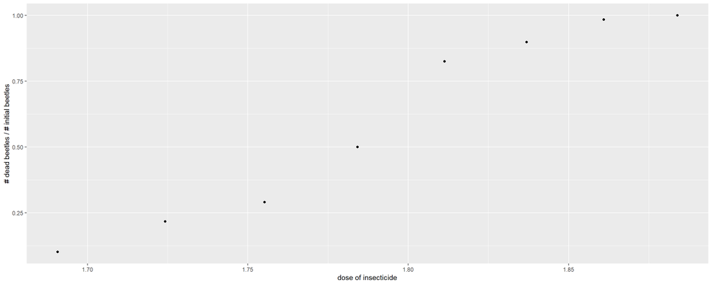

Given the number n_i of total beetles we want to predict how many of them will be killed r_i given that they are exposed on a concentracion x_i of insecticide. The model is binomial, given n_i trials we get r_i successes and we want to evaluate what is the probability of success p_i. We assume that the p_i depends somehow by the concentration x_i. The easisest dependce we can assume between p and x is a linear one, but since p is a probability we should sqeeze this lienear dependce to the domain of probabilities, i.e. using a link function. For this model we will assume as models: p_i = sigmoid(beta0+beta1*x_i), p_i = Phi(beta0+beta1*x_i) and p_i = (tanh(beta0+beta1*x_i)+1)/2. As priors for beta0 and beta1 we are going to use : N(0,0.001).

We are going now to simulate a Markov chain, for all the 3 models, to draw random variables from the posterior distribution to be able to estimate quantities of interest.

```r
data_model = list("r","n","N","x")
parameters_model = c("beta0","beta1")

model_inits = function(){
  list("beta0" = rnorm(0, sqrt(1000)),
       "beta1" = rnorm(0, sqrt(1000))
       )
}

sigmoid_model = function(){
  for(i in 1:N){
    r[i] ~ dbin(p[i],n[i])
    # standardization as suggested by Chapman in chapter 8
    logit(p[i]) = beta0_jnk + beta1*(x[i]-mean(x[]))
  }
  beta0 = beta0_jnk - beta1*mean(x[])
  beta0_jnk ~ dnorm(0,0.001)
  beta1 ~ dnorm(0,0.001)
}

probit_model = function(){
  for(i in 1:N){
    r[i] ~ dbin(p[i],n[i])
    p[i] = phi(beta0_jnk + beta1*( x[i]-mean(x[]) ) )
  }

  beta0 = beta0_jnk - beta1*mean(x[])
  beta0_jnk ~ dnorm(0,0.001)
  beta1 ~ dnorm(0,0.001)
}

tanh_model = function(){
  for(i in 1:N){
    r[i] ~ dbin(p[i],n[i])
    #cloglog(p[i]) = beta0 + beta1*(x[i] - mean(x[]))
    p[i] = (tanh(beta0_jnk+beta1*(x[i]-mean(x[])))+1)/2
  }

  beta0 = beta0_jnk - beta1*mean(x[])
  beta0_jnk ~ dnorm(0,0.001)
  beta1 ~ dnorm(0,0.001)
}
sigmoid_chain = jags(data = data_model,                                    # DATA
                      model.file = sigmoid_model, inits = model_inits,          # MODEL
                      parameters.to.save = parameters_model,
                      n.chains = 3, n.iter = 100000, n.burnin = 2000, n.thin=10)
```

```
## module glm loaded
```

```r
probit_chain = jags(data = data_model,                                    # DATA
                      model.file = probit_model, inits = model_inits,          # MODEL
                      parameters.to.save = parameters_model,
                      n.chains = 3, n.iter = 100000, n.burnin = 2000, n.thin=10)
tanh_chain = jags(data = data_model,                                    # DATA
                      model.file = tanh_model, inits = model_inits,          # MODEL
                      parameters.to.save = parameters_model,
                      n.chains = 3, n.iter = 100000, n.burnin = 2000, n.thin=10)
print(sigmoid_chain)
```

```
## Inference for Bugs model at "C:/Users/dilar/AppData/Local/Temp/RtmpMrA7SS/model22d4f5c1120.txt", fit using jags,
##  3 chains, each with 1e+05 iterations (first 2000 discarded), n.thin = 10
##  n.sims = 29400 iterations saved
##          mu.vect sd.vect    2.5%     25%     50%     75%   97.5%  Rhat
## beta0    -60.771   5.189 -71.338 -64.163 -60.591 -57.238 -51.054 1.001
## beta1     34.300   2.918  28.836  32.315  34.198  36.213  40.229 1.001
## deviance  39.432   2.699  37.481  38.019  38.816  40.184  44.640 1.001
##          n.eff
## beta0    29000
## beta1    29000
## deviance  6500
##
## For each parameter, n.eff is a crude measure of effective sample size,
## and Rhat is the potential scale reduction factor (at convergence, Rhat=1).
##
## DIC info (using the rule, pD = var(deviance)/2)
## pD = 3.6 and DIC = 43.1
## DIC is an estimate of expected predictive error (lower deviance is better).
```

```r
print(probit_chain)
```

```
## Inference for Bugs model at "C:/Users/dilar/AppData/Local/Temp/RtmpMrA7SS/model22d46a355700.txt", fit using jags,
##  3 chains, each with 1e+05 iterations (first 2000 discarded), n.thin = 10
##  n.sims = 29400 iterations saved
##          mu.vect sd.vect    2.5%     25%     50%     75%   97.5%  Rhat
## beta0    -35.038   2.643 -40.306 -36.795 -35.008 -33.257 -29.916 1.001
## beta1     19.787   1.486  16.900  18.784  19.770  20.772  22.750 1.001
## deviance  38.311   1.996  36.368  36.892  37.701  39.087  43.676 1.001
##          n.eff
## beta0    29000
## beta1    29000
## deviance 29000
##
## For each parameter, n.eff is a crude measure of effective sample size,
## and Rhat is the potential scale reduction factor (at convergence, Rhat=1).
##
## DIC info (using the rule, pD = var(deviance)/2)
## pD = 2.0 and DIC = 40.3
## DIC is an estimate of expected predictive error (lower deviance is better).
```

```r
print(tanh_chain)
```

```
## Inference for Bugs model at "C:/Users/dilar/AppData/Local/Temp/RtmpMrA7SS/model22d471d51ea6.txt", fit using jags,
##  3 chains, each with 1e+05 iterations (first 2000 discarded), n.thin = 10
##  n.sims = 29400 iterations saved
##          mu.vect sd.vect    2.5%     25%     50%     75%   97.5%  Rhat
## beta0    -30.580   2.598 -35.878 -32.275 -30.502 -28.795 -25.662 1.001
## beta1     17.260   1.460  14.497  16.259  17.215  18.215  20.242 1.001
## deviance  39.422   2.007  37.479  38.003  38.792  40.177  44.846 1.001
##          n.eff
## beta0    20000
## beta1    21000
## deviance 29000
##
## For each parameter, n.eff is a crude measure of effective sample size,
## and Rhat is the potential scale reduction factor (at convergence, Rhat=1).
##
## DIC info (using the rule, pD = var(deviance)/2)
## pD = 2.0 and DIC = 41.4
## DIC is an estimate of expected predictive error (lower deviance is better).
```

As we can notice the chains produce reasonable results and from the DIC scores we see that the models are all close to eachother.

We can focus on the probit model and verify that the chain is stabile. We can evaluate the quality of the chain by looking at the traceplot of each parameter and the effective sample sizes. From the traceplots the chains looks stabile and the autocorrelation decays pretty fast, this means that the effective sample size is close to the real sample size and the variance of the sample mean is the variance of the chain divided by the number of simulated parameters.

```r
emp_avg_over_time = function(vec, step){
  # given one vector vec this function evaluates the mean of the truncated vector vec[1:t], where t increases by the step
  # at each iteration.
  # length(vec)/step should be an integer
  avg_vec = rep(NA, length(vec)/step)
  for(i in 1:length(vec)/step){
    avg_vec[i] = mean(vec[1:i*step])
  }
  return(avg_vec)
}
```

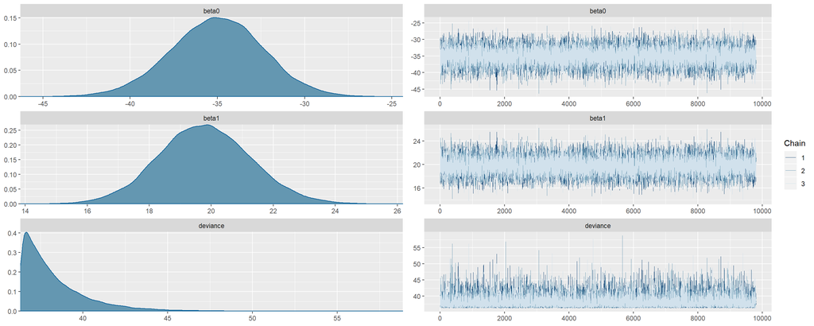

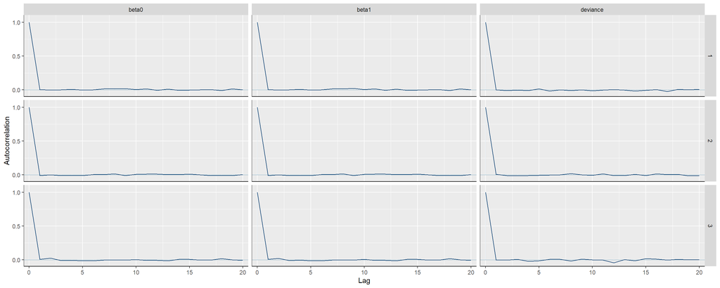

```
##
## The effective sample sizesfor the 2 parameters are: 28861.14 28864.15
## Variance of sample means: 0.0002420003 7.65236e-05
```

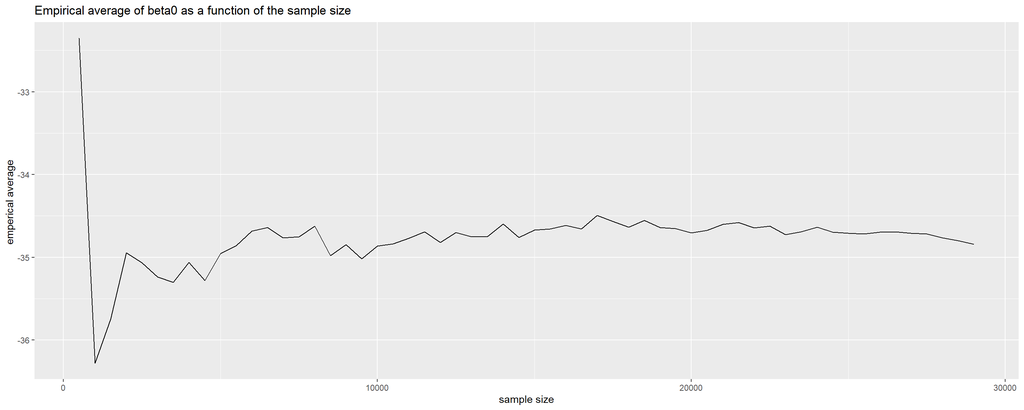

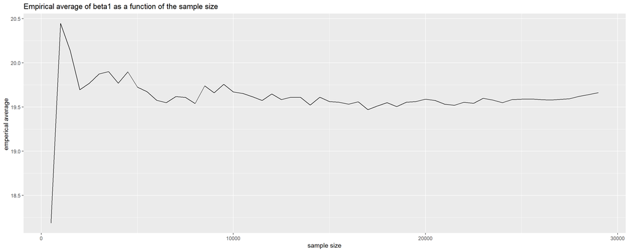

From the last 2 graphs we see the empirical averages as a function of the sample size and with good approximation they converge after approximately 5000 samples.

Predictions: In the figures we use the empirical averages of the parameters drawn from the posterior to plot the predicted p(x) against the data points.

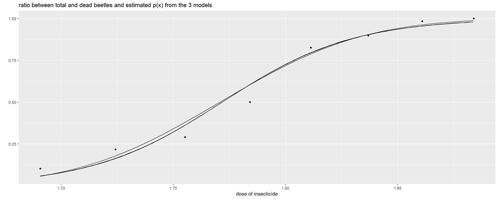

```
## Parameters averages and sd for the 3 models
```

```
##       sigmoid mean sigmoid sd probit mean probit sd tanh mean  tanh sd
## beta0    -60.77128   5.189256   -35.03831  2.642803 -30.58046 2.597604
## beta1     34.30040   2.918087    19.78668  1.486199  17.26016 1.459701
```

```
##
## Equitail credible intervals at level 95%
```

```
##       sigmoid lower sigmoid upper probit lower probit upper tanh lower
## beta0     -71.33819     -51.05431    -40.30633    -29.91557  -35.87814
## beta1      28.83643      40.22925     16.89993     22.74959   14.49699
##       tanh upper
## beta0  -25.66234
## beta1   20.24237
```

```
##
## Comparison through DIC
## sigmoid model: 43.07459
## probit model: 40.30231
## tanh model: 41.43498
## As we can see the best model is: probit
```

Further step is to predict the distribution for the number of dead beetles given the number of total beetles and the dose of insecticide. To do so we need the expected value of the conditional model evaluated in the points r_new,n_new,x_new, w.r.t. the posterior distribution. To estimate the expectation we can use the MC.

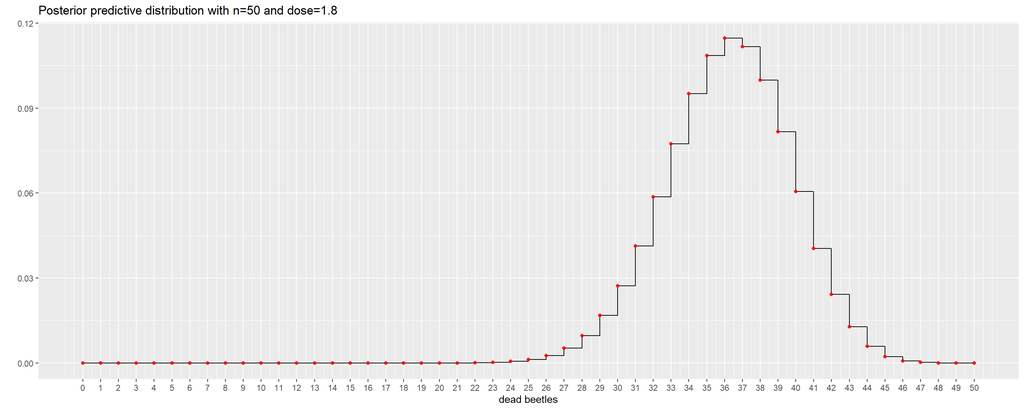

```r
predictive_p = function(r_new, n_new,x_new){
  average = 0
  for (i in 1:probit_chain$BUGSoutput$n.sims){
    average = average +   dbinom(x=r_new, size=n_new, prob=pnorm(probit_chain$BUGSoutput$sims.matrix[i,1] +  probit_chain$BUGSoutput$sims.matrix[i,2]*x_new))
  }
  return(average/probit_chain$BUGSoutput$n.sims)
}


ggplot()+
  geom_step(aes(x=rep(0:50), y=predictive_p(0:50,50,1.8)))+
  geom_point(aes(x=rep(0:50), y=predictive_p(0:50,50,1.8)),color="red",alpha=0.85)+
  scale_x_continuous(breaks = seq(0,50,1))+
  xlab("dead beetles")+ ylab("")+
  ggtitle("Posterior predictive distribution with n=50 and dose=1.8")
```

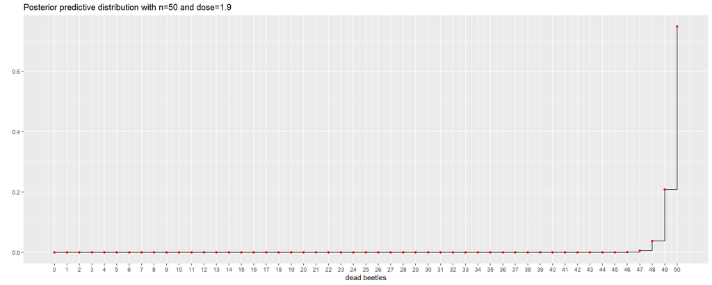

```r
ggplot()+
  geom_step(aes(x=rep(0:50), y=predictive_p(0:50,50,1.9)))+
  geom_point(aes(x=rep(0:50), y=predictive_p(0:50,50,1.9)),color="red",alpha=0.85)+
  scale_x_continuous(breaks = seq(0,50,1))+
  xlab("dead beetles")+ylab("")+
  ggtitle("Posterior predictive distribution with n=50 and dose=1.9")
```

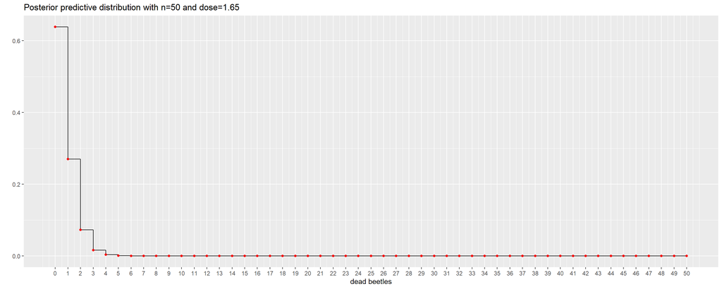

```r
ggplot()+
  geom_step(aes(x=rep(0:50), y=predictive_p(0:50,50,1.65)))+
  geom_point(aes(x=rep(0:50), y=predictive_p(0:50,50,1.65)),color="red",alpha=0.85)+
  scale_x_continuous(breaks = seq(0,50,1))+
  xlab("dead beetles")+ylab("")+
  ggtitle("Posterior predictive distribution with n=50 and dose=1.65")
```

To further verify the correctness of the model we can simulate data from it and check if the chain works correctly:

```r
beta0 = -20
beta1 = 10

simulated_p = pnorm(beta0+beta1*x)

simulated_r = rep(NA, N)
for(i in 1:N){
  simulated_r[i] = rbinom(n=1,prob=simulated_p[i],size=n[i])
}

data_model_simul = list("simulated_r","n","N","x")

probit_model = function(){
  for(i in 1:N){
    simulated_r[i] ~ dbin(p[i],n[i])
    p[i] = phi(beta0_jnk + beta1*( x[i]-mean(x[]) ) )
  }

  beta0 = beta0_jnk - beta1*mean(x[])
  beta0_jnk ~ dnorm(0,0.001)
  beta1 ~ dnorm(0,0.001)
}
probit_chain_simul = jags(data = data_model_simul,                                    # DATA
                      model.file = probit_model, inits = model_inits,          # MODEL
                      parameters.to.save = parameters_model,
                      n.chains = 3, n.iter = 100000, n.burnin = 15000, n.thin=10)
print(probit_chain_simul)
```

```
## Inference for Bugs model at "C:/Users/dilar/AppData/Local/Temp/RtmpMrA7SS/model22d4b3575d3.txt", fit using jags,
##  3 chains, each with 1e+05 iterations (first 15000 discarded), n.thin = 10
##  n.sims = 25500 iterations saved
##          mu.vect sd.vect    2.5%     25%     50%     75%  97.5%  Rhat
## beta0    -16.511   5.525 -28.387 -19.989 -16.141 -12.639 -6.763 1.001
## beta1      7.955   3.003   2.634   5.850   7.757   9.846 14.399 1.001
## deviance  21.692   1.987  19.734  20.261  21.096  22.478 27.039 1.001
##          n.eff
## beta0    26000
## beta1    26000
## deviance 26000
##
## For each parameter, n.eff is a crude measure of effective sample size,
## and Rhat is the potential scale reduction factor (at convergence, Rhat=1).
##
## DIC info (using the rule, pD = var(deviance)/2)
## pD = 2.0 and DIC = 23.7
## DIC is an estimate of expected predictive error (lower deviance is better).
```